# Intro to statistics with R

#### 5. Parametric and non-parametric methods

Statistical methods can be **parametric** or **non-parametric**. Both assume that the data come from a *random* sample and often also that the observations are *independent* (meaning that the value of an observation is not affected by other observations). However, there are also many key differences.

**Parametric methods**

Let’s have a look at some of the key features that define parametric tests:

- Parametric methods make assumptions about the underlying distribution of the data. A common scenario is the assumption of *normality*, i.e. adherence to the normal (or Gaussian) distribution. Many natural phenomena tend to follow the normal distribution, which is shaped like a bell curve. To see this in practice, let’s create a histogram:

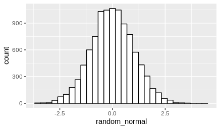

```r
# generate random data from normal distribution using rnorm()
random_normal = rnorm(10000, mean = 0, sd = 1)
# creates vector with mean of 0 and standard deviation of 1

# convert to data frame
random_normal <- data.frame(random_normal)

# histogram of the data
ggplot(random_normal, aes(x = random_normal)) +
  geom_histogram(color = "black", fill = "white")
```

- The assumption of normality can apply to either the observations or to *residuals* (i.e. differences between your observations and a set of predicted values). We will talk more about residuals soon!
- Parametric methods assume a *homogeneity of variance* between groups. For example, we might want to compare the `flipper_len` representing flipper length of males and females in the `penguins` data set. A parametric test would assume the values in the two groups to have equal variances.
- Parametric methods use the mean as a measure of central tendency (in practice this means that they rely on comparisons of group means).

**Non-parametric methods**

In contrast to their parametric counterparts, non-parametric methods:

- Do not assume a particular distribution or the homogeneity of variances. They still make other assumptions (while they are sometimes called “distribution-free”, they are never assumption-free).
- Are suitable for the analysis of data measured at the *nominal* level (such as names and labels).
- Employ the median as a measure of central tendency. This is important because if the study aim is to compare group medians rather than means, a non-parametric test might be preferable (even if the data could otherwise be analyzed using a parametric approach).

#### 5. How to put things into practice

With real data, things practically never look as neat as they did in the example above. For example, the distributions may be *skewed* or you might see multiple peaks (or *modes*). Parametric methods are nevertheless often recommended because:

- When the assumptions are met, they are more sensitive than non-parametric analyses (you are more likely to detect an effect if there is one).
- If the assumptions are not met, it may be possible to address this by *transforming* the data (e.g. using a log or *x*+1 transformation). The idea is that transformations can help address issues including non-normality without affecting the relationship between observations (since all the data are subjected to the same transformation).

Remember that in some cases a non-parametric test might be your best option to start with! The steps taken for these are very similar: describe the data, check that the assumptions are met, then go ahead with significance testing.

**Discussion**

Spend up to 10 minutes (~2 mins per person ) taking turns to discuss the types of data you deal with in your work (or data you’re anticipating to generate). Which types of statistical tests are likely to be the most suitable for these - parametric or non-parametric?

#### 6. Examples of statistical methods

We are now ready to learn about some common statistical techniques and how to use them in R. We will start with two parametric methods (*t*-test and linear regression), after which we will move onto the Chi-squared (*χ*<sup>2</sup>) test as an example of a non-parametric method.